# assing

## 5. Conversion of Datatype of column published_at to pandas datetime

```python
#   To be in a safe side copying of series into a variable prevent if any mistake is done to the root dataframe (original Dataframe)
b=pd.to_datetime(a['published_at'],format='%Y-%m-%d %H:%M:%S').copy()   #   b is a temporary Variable which takes up published_at Column as datetime64 datatype
b                                                                       #   pd.to_datetime function converts the string(object datatype) into datetime Datatype by feeding the format of the string given
```

```
0       2021-07-01 10:00:00
1       2021-06-10 16:00:00
2       2021-09-20 01:03:32
3       2021-03-03 10:00:17
4       2021-12-07 13:00:00
                ...
37417   2021-02-12 05:03:49
37418   2021-01-16 05:39:05
37419   2021-06-02 09:00:10
37420   2020-10-20 20:59:30
37421   2021-05-23 21:00:31
Name: published_at, Length: 37264, dtype: datetime64[ns]
```

```python
a['published_at']=b             #   So the Previous Code cells there we no error so we can replace the Column with the Temporay Series Variable
a.published_at.dtype            #   Returns the Datatype of the Column of published_at to confirm its a Datetime DataType
```

```
dtype('<M8[ns]')
```

## 6. To Create a Column published_month using the column published_at Display all the months.

```python
#   Again to be in Safe side a temporary variable is used to store the info without tampering the Main DataFrame

b=pd.DatetimeIndex(a['published_at']).month.copy()         #   This Functions returns the Month in Number(1,2 as Jan , Feb) and stores in temporary b
```

```python
b                           #   To Show whats in b and to Confirm what we need
```

```
Int64Index([ 7,  6,  9,  3, 12, 12, 10,  3,  8,  8,
            ...
             8,  8,  8, 12, 11,  2,  1,  6, 10,  5],
           dtype='int64', name='published_at', length=37264)
```

```python
a['published_month']=b      #   To store b in a new column named published_month
```

```python
a.published_month.head(3)   #   To show whats in a['published_month']
```

```
0    7
1    6
2    9
Name: published_month, dtype: int64
```

## 7. Replace the Numbers as Months as Jan , Feb

```python
#   Again to be in Safe side a temporary variable is used to store the Main DataFrame info without tampering the Main DataFrame

b=a['published_month'].copy()   #   Copying into b
```

```python
b.info()                        #   To Find what is in temporary variable b
```

```
<class 'pandas.core.series.Series'>
Int64Index: 37264 entries, 0 to 37421
Series name: published_month
Non-Null Count  Dtype
--------------  -----
37264 non-null  int64
dtypes: int64(1)
memory usage: 582.2 KB
```

```python
#   To Create a function which has a dictionay of keys 1-12 and values 'Jan'-'Dec' Respectively
#   And Map the Numbers to Name of the Month as Jan , Feb ...
#   And at End it returns a Series which contains Month Names instead of Month Numbers respectively

def mon(x):
    num=[1,2,3,4,5,6,7,8,9,10,11,12]                                                #   Month Numbers
    mo=['Jan','Feb','Mar','Apr','May','Jun','Jul','Aug','Sep','Oct','Nov','Dec']    #   Month Names
    m=dict(zip(num,mo))                                                             #   Making it a Dict to map it
    c=x.map(m)                                                                      #   Creating a series c and maping it with the Dictionary
    return c                                                                        #   Returns the series c
```

```python
pd.DataFrame(mon(b),b)                  #   Created a DataFrame (For clean output) to show the Month Number and Month Names Match each other
```

| published_month | published_month |
| --- | --- |
| 7 | Mar |
| 6 | Oct |
| 9 | Aug |
| 3 | Mar |
| 12 | Jul |
| ... | ... |
| 2 | Sep |
| 1 | Jun |
| 6 | Oct |
| 10 | Sep |
| 5 | Dec |

37264 rows × 1 columns

```python
a['published_month']=mon(b)             #   Creating a New Column named published_month and store the Series mon(b) which returns Month Names as Object DataType
```

## 8. Number of Videos published each month and arrange the months in a decreasing order

```python
b=a.published_month.value_counts()              #   A variable b is created which contains the count of the Months repeated
```

```python
print(b.sort_values(ascending=False))           #   Function which print the Sorted Value counts of months in Decending Order
```

```
Oct    4976
Sep    4854
Nov    4821
Aug    4250
Dec    3063
Jul    2331
Jun    2305
Mar    2248
Feb    2125
Apr    2119
Jan    2099
May    2073
Name: published_month, dtype: int64
```

## 9. Count of Unique video_id , channel_id and channel_title

```python
#   Copying the columns video_id , channel_id , channel_title into 3 different variables b1,b2,b3 respectively

b1,b2,b3=a.video_id.copy(),a.channel_id.copy(),a.channel_title.copy()
```

```python
c1=b1.unique().size    #   Returns the Number of unique video_id
c1
```

```
37264
```

```python
c2=b2.unique().size    #   Returns the Number of unique channel_id
c2
```

```
10891
```

```python
c3=b3.unique().size    #   Returns the Number of unique channel_title
c3
```

```
10813
```

```python
# d1,d2,d3 = b1.unique().size,b2.unique().size,b3.unique().size               # Other ways to put it in a line
# d1,d2,d3
```

```python
print(f'Number of Unique \nvideo_id are \t\t:{c1}, \nchannel_id are \t\t:{c2} and \nchannel_title are \t:{c3}.')
```

```
Number of Unique
video_id are 		:37264,
channel_id are 		:10891 and
channel_title are 	:10813.
```

## 10. Top 10 Channel names having the highest number of videos in the dataset and the bottom10 having lowest number of videos.

```python
#   Storing the Channel Title in a Temporary Variable
b=a.channel_title.value_counts().copy()     #   Since the data set 1 row contains descreption of 1 video so the value count of the channel_title gives out number of time the channel posted videos
```

```python
b               #   By default the Function value_counts() Arranges in Decending Order
```

```
Sky Sports Football        533
The United Stand           301
BT Sport                   246
NBA                        209
NFL                        162
                          ...
JFlaMusic                    1
Ron Bielecki                 1
GLAD Empire                  1
Hip Hop News Uncensored      1
Master Podcast               1
Name: channel_title, Length: 10813, dtype: int64
```

```python
b[:10]          #   This Prints the Top 10 channel_title of highest number of Videos
```

```
Sky Sports Football    533
The United Stand       301
BT Sport               246
NBA                    209
NFL                    162
WWE                    122
SSSniperWolf            99
SSundee                 98
FORMULA 1               87
NHL                     86
Name: channel_title, dtype: int64
```

```python
b[-10:]          #   This Prints the Top 10 channel_title of lowest number of Videos
```

```
Ohio State Football          1
boqer123                     1
xisumatwo                    1
Gaming with Griff Griffin    1
KoncreteJungle               1
JFlaMusic                    1
Ron Bielecki                 1
GLAD Empire                  1
Hip Hop News Uncensored      1
Master Podcast               1
Name: channel_title, dtype: int64
```

## 11. Find title of video which has maximum no of likes and the title of video having minimum likes.

##### Using max function and getting the Max value and matching the index of it to get the index of the max likes

```python
#   Copying into a variable to avoid Tampering the Main DataFrame
b=a.copy()
```

```python
#   Variable = b.index(b['Column']==b['Column'].max()) The idea is to match the maximum value to the same column and so we get the boolean value and from that to get the Index Value
#   The same format is used for the minimum and other columns to get the index.

b1=list(b.index[b['likes']==b['likes'].max()])      #   The Index value of Maximum Value in the Column is stored in Variable b1
b2=list(b.index[b['likes']==b['likes'].min()])      #   The Index Value of Minimum Value in the Column is stored in Variable b2
print(b1[0],b2[0])                                  #   Index values of Maximum and Minimum is printed to Confirm it

#   The output is converted to a list since it gives out index and datatype which is a pandas series and to simplify it.
#   Like in the Below Cell which shows the output of it
```

```
26143 23855
```

```python
b.index[b['likes']==b['likes'].max()]
```

```
Int64Index([26143], dtype='int64')
```

#### Using the Index and retreving Title

```python
#   The property here we should use is loc because the it prints the Index assigned at the very beginning which is labelled at very beginning and is not changed
#   Since we have dropped the rows which contains NaN values the Index label is not affected anywhere until it is resetted.
#   When we use iloc it give us position based output.


b.loc[b1].title,b.iloc[b1].title
```

```
(26143    BTS () 'Dynamite' Official MV
 Name: title, dtype: object,
 26243    Adele - To Be Loved
 Name: title, dtype: object)
```

```python
#   Using the loc property which takes in Index and retrieving the Title Column

t1=list(b.loc[b1].title)
t2=list(b.loc[b2].title)
print(f'The Title With Maximum Likes\t:\t{t1[0]} ,\nThe title with Minimum Likes\t:\t{t2[0]}.')
```

```
The Title With Maximum Likes	:	BTS () 'Dynamite' Official MV ,
The title with Minimum Likes	:	Leading the Charge | Circle K.
```

```python
#   The Whole Operation in 1 line for (max likes and min likes)

(list(b.loc[list(b.index[b['likes']==b['likes'].max()])].title)[0],list(b.loc[list(b.index[b['likes']==b['likes'].min()])].title)[0])
```

```
("BTS () 'Dynamite' Official MV", 'Leading the Charge | Circle K')
```

## 12. To find the title of the video which has maximum and minimum number of dislikes

```python
#   Using the same operations for the previous question using it here for dislikes column

b1=list(b.index[b['dislikes']==b['dislikes'].max()])
b2=list(b.index[b['dislikes']==b['dislikes'].min()])
print(b1,b2)
```

```
[13591] [29482]
```

```python
t1=list(b.loc[b1].title)
t2=list(b.loc[b2].title)
print(f'The Title With Maximum Disikes\t:\t{t1[0]} ,\nThe title with Minimum Disikes\t:\t{t2[0]}.')
```

```
The Title With Maximum Disikes	:	Cuties | Official Trailer | Netflix ,
The title with Minimum Disikes	:	Tims For Good: A Taste Of The Familiar.
```

## 13. Does the number of views have any effect on how many people disliked the video? support your answer with a metric and a plot

### Taking Temporary Variables to store required Data

3 Different Sorted Data from the Main Data Frame is taken to Find the Assumption

```python
c1=b.sort_values(by='likes',ascending=False)[:10][['title','likes','dislikes','view_count']]
# b.sort_values(by='likes',ascending=False)[:10][['title','likes','dislikes','view_count']]
```

```python
c2=b.sort_values(by='dislikes',ascending=False)[:10][['title','dislikes','likes','view_count']]
# b.sort_values(by='dislikes',ascending=False)[:10][['title','dislikes','likes','view_count']]
```

```python
b=a.copy()
c3=b.sort_values(by='view_count',ascending=False)[:10][['title','likes','dislikes','view_count']]
# b.sort_values(by='likes',ascending=False)[:10][['title','view_count','likes','dislikes']]
```

### Mini Data Frame to Focus to find the Assumption

```python
c1
```

|  | title | likes | dislikes | view_count |
| --- | --- | --- | --- | --- |
| 26143 | BTS () 'Dynamite' Official MV | 31837675 | 1814333 | 1322796924 |
| 19583 | BTS () 'Butter' Official MV | 20649409 | 467125 | 638732230 |
| 34758 | BLACKPINK - 'Ice Cream (with Selena Gomez)' M/V | 17864527 | 1253187 | 671712535 |
| 57 | BTS () 'Life Goes On' Official MV | 16354127 | 281252 | 412591136 |
| 8176 | BTS () 'Permission to Dance' Official MV | 15449003 | 279664 | 392440299 |
| 22870 | LISA - 'LALISA' M/V | 14680271 | 253593 | 369525630 |
| 24598 | BLACKPINK - 'Lovesick Girls' M/V | 13641573 | 325697 | 518378576 |
| 30874 | THIS NEARLY GAVE HIM A HEART ATTACK! | 12219447 | 620645 | 336817144 |
| 950 | $456,000 Squid Game In Real Life! | 11729606 | 83338 | 160234180 |
| 9644 | Bella Poarch - Build a B*tch (Official Music V... | 10734829 | 441706 | 340284935 |

```python
c2
```

|  | title | dislikes | likes | view_count |
| --- | --- | --- | --- | --- |
| 13591 | Cuties \| Official Trailer \| Netflix | 2397733 | 94569 | 17996395 |
| 26143 | BTS () 'Dynamite' Official MV | 1814333 | 31837675 | 1322796924 |
| 26894 | Cardi B - WAP feat. Megan Thee Stallion [Offic... | 1331181 | 8140694 | 432214292 |
| 7955 | 52 GAJ KA DAMAN \| PRANJAL DAHIYA \| AMAN JAJI \|... | 1259533 | 6326231 | 1269596718 |
| 34758 | BLACKPINK - 'Ice Cream (with Selena Gomez)' M/V | 1253187 | 17864527 | 671712535 |
| 4716 | Lil Nas X - MONTERO (Call Me By Your Name) (Of... | 1224559 | 9551666 | 404190118 |
| 25765 | Tip Chocolate Hacks With Balloon | 802354 | 9689693 | 347329515 |
| 21473 | Coke & Mentos Bottle INSIDE Balloon!! *Experim... | 724993 | 6657200 | 305556145 |
| 21252 | A STORY ABOUT GREED | 643536 | 6336223 | 198059677 |
| 30874 | THIS NEARLY GAVE HIM A HEART ATTACK! | 620645 | 12219447 | 336817144 |

```python
c3
```

|  | title | likes | dislikes | view_count |
| --- | --- | --- | --- | --- |
| 26143 | BTS () 'Dynamite' Official MV | 31837675 | 1814333 | 1322796924 |
| 7955 | 52 GAJ KA DAMAN \| PRANJAL DAHIYA \| AMAN JAJI \|... | 6326231 | 1259533 | 1269596718 |
| 18127 | BAD BUNNY x JHAY CORTEZ - DKITI (Video Oficial) | 7496062 | 290062 | 976281963 |
| 16270 | KAROL G - BICHOTA | 5713346 | 489286 | 915874131 |
| 34758 | BLACKPINK - 'Ice Cream (with Selena Gomez)' M/V | 17864527 | 1253187 | 671712535 |
| 31864 | Camilo - Vida de Rico (Official Video) | 5373238 | 330334 | 669202777 |
| 19583 | BTS () 'Butter' Official MV | 20649409 | 467125 | 638732230 |
| 20299 | The Weeknd - Save Your Tears (Official Music V... | 5225411 | 178037 | 620327393 |
| 17776 | Naach Meri Rani: Guru Randhawa Feat. Nora Fate... | 5452259 | 517705 | 580564915 |
| 2213 | KAROL G, Mariah Angeliq - EL MAKINON (Official... | 3346080 | 194973 | 562716952 |

### Ploting a Bar Graph

Using the Same template to all the 3 different sorted Data set to plot a Bar Graph and to infer it

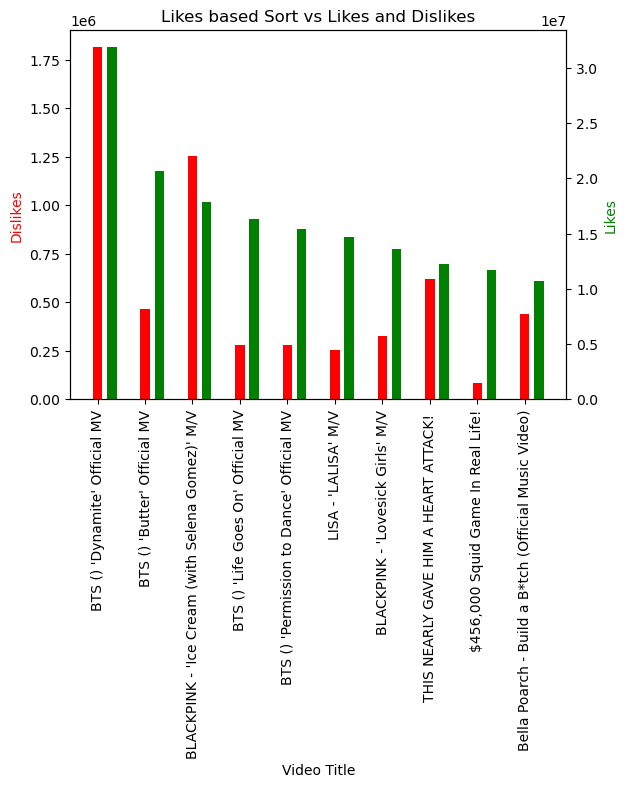

```python
#   Based on Sorted Likes

#   Storing Title , Dislikes , Likes in a temporary variable for easier to call
d1=c1.title
d2=c1.dislikes
d3=c1.likes

#   To Create Figure and Axes
fig, ax1 = plt.subplots()
plt.xticks(rotation=90)
#   To plot Title
plt.title('Likes based Sort vs Likes and Dislikes')
#   To Plot the Title of the X axis
plt.xlabel('Video Title')


#   To Create Position
br1=np.arange(len(d2))
br2=[x + 0.3 for x in br1]

#   To Create a left axis of Dislikes
ax1.bar(d1,d2,color='red',label='Dislikes',width=0.2)
ax1.set_ylabel('Dislikes',c='red')

#   To Create a TwinX axis which shares the same x axis
ax2=ax1.twinx()

#   To Create a Right Axis of Likes
ax2.bar(br2,d3,color='Green',label='Likes',width=0.2)
ax2.set_ylabel('Likes',c='Green')

#   To Plot the Figure
plt.show()
```

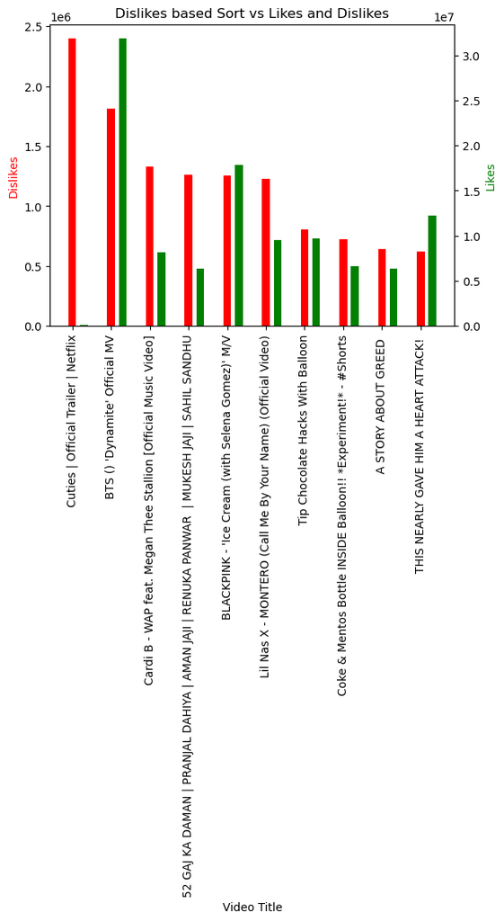

```python
#   Based on Sorted Dislikes

#   Storing Title , Dislikes , Likes in a temporary variable for easier to call
d1=c2.title
d2=c2.dislikes
d3=c2.likes

#   To Create Figure and Axes
fig, ax1 = plt.subplots()
plt.xticks(rotation=90)
#   To plot Title
plt.title('Dislikes based Sort vs Likes and Dislikes')
#   To Plot the Title of the X axis
plt.xlabel('Video Title')


#   To Create Position
br1=np.arange(len(d2))
br2=[x + 0.3 for x in br1]

#   To Create a left axis of Dislikes
ax1.bar(d1,d2,color='red',label='Dislikes',width=0.2)
ax1.set_ylabel('Dislikes',c='red')

#   To Create a TwinX axis which shares the same x axis
ax2=ax1.twinx()

#   To Create a Right Axis of Likes
ax2.bar(br2,d3,color='Green',label='Likes',width=0.2)
ax2.set_ylabel('Likes',c='Green')

#   To Plot the Figure
plt.show()
```

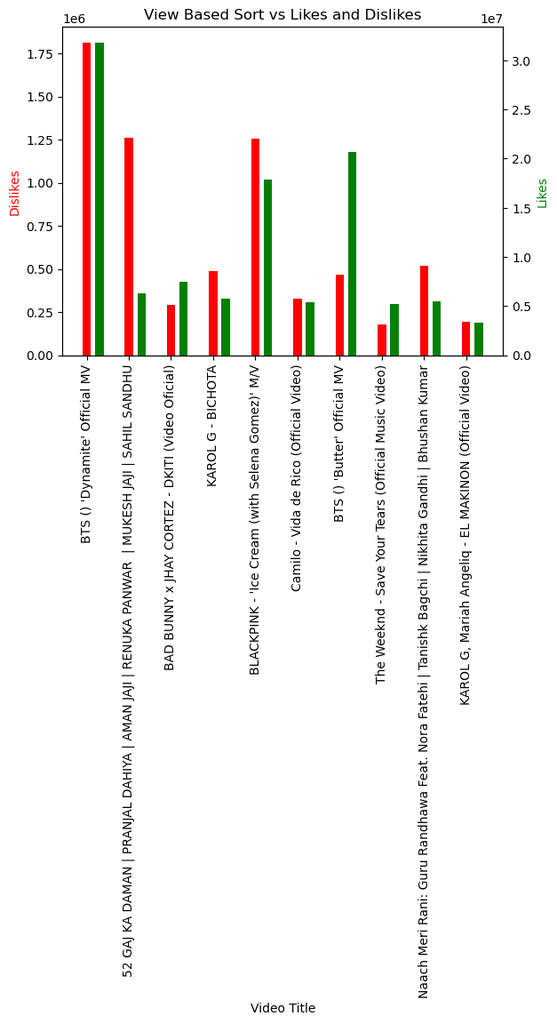

```python
#   Based on Sorted view_count

#   Storing Title , Dislikes , Likes in a temporary variable for easier to call
d1=c3.title
d2=c3.dislikes
d3=c3.likes

#   To Create Figure and Axes
fig, ax1 = plt.subplots()
plt.xticks(rotation=90)
#   To plot Title
plt.title('View Based Sort vs Likes and Dislikes')
#   To Plot the Title of the X axis
plt.xlabel('Video Title')


#   To Create Position
br1=np.arange(len(d2))
br2=[x + 0.3 for x in br1]

#   To Create a left axis of Dislikes
ax1.bar(d1,d2,color='red',label='Dislikes',width=0.2)
ax1.set_ylabel('Dislikes',c='red')

#   To Create a TwinX axis which shares the same x axis
ax2=ax1.twinx()

#   To Create a Right Axis of Likes
ax2.bar(br2,d3,color='Green',label='Likes',width=0.2)
ax2.set_ylabel('Likes',c='Green')

#   To Plot the Figure
plt.show()
```